# Personalized Reading Recommendations from a Book Dataset

This is a book recommendation system which recommends 5 books based on your taste and preference. The dataset holds variety of information about a book for instance, its ratings, authors, publishers and more. Some of these information are typically used in order to determine the taste of a user and make appropriate personaized reading recommendations.

Following are the imports which are necessary

```python
import numpy as np
import pandas as pd
import csv
import matplotlib.pyplot as plt
from sklearn.feature_extraction.text import CountVectorizer
from sklearn.metrics.pairwise import cosine_similarity
import seaborn as sns
from sklearn.feature_extraction.text import TfidfVectorizer
import plotly.express as px
```

# Task - 1 : Performing EDA(Exploratory Data Analysis on book data)

## About the data:

The data consist comprehensive list of books listed in goodreads. It consist typically 12 columns (bookID, title, authors, average_rating, isbn, isbn13, language_code, num_pages , ratings_count, text_reviews_count, publication_date, publisher)

## Why EDA?

EDA facilitates the identification of missing values, outliers, and inconsistencies in the data, enabling data cleaning and preprocessing tasks. It also helps in formulating research questions, refining hypotheses, and selecting appropriate modeling techniques for further analysis. By uncovering patterns and insights, EDA provides a foundation for making informed decisions and guiding subsequent data-driven investigations or predictive modeling tasks.

```python
#Reading the database by loading the CSV file
data = pd.read_csv(r'C:\Users\aniru\Music\books.csv', on_bad_lines='skip')
data
```

|  | bookID | title | authors | average_rating | isbn | isbn13 | language_code | num_pages | ratings_count | text_reviews_count | publication_date | publisher |
| --- | --- | --- | --- | --- | --- | --- | --- | --- | --- | --- | --- | --- |
| 0 | 1 | Harry Potter and the Half-Blood Prince (Harry ... | J.K. Rowling/Mary GrandPré | 4.57 | 0439785960 | 9780439785969 | eng | 652 | 2095690 | 27591 | 9/16/2006 | Scholastic Inc. |
| 1 | 2 | Harry Potter and the Order of the Phoenix (Har... | J.K. Rowling/Mary GrandPré | 4.49 | 0439358078 | 9780439358071 | eng | 870 | 2153167 | 29221 | 9/1/2004 | Scholastic Inc. |
| 2 | 4 | Harry Potter and the Chamber of Secrets (Harry... | J.K. Rowling | 4.42 | 0439554896 | 9780439554893 | eng | 352 | 6333 | 244 | 11/1/2003 | Scholastic |
| 3 | 5 | Harry Potter and the Prisoner of Azkaban (Harr... | J.K. Rowling/Mary GrandPré | 4.56 | 043965548X | 9780439655484 | eng | 435 | 2339585 | 36325 | 5/1/2004 | Scholastic Inc. |
| 4 | 8 | Harry Potter Boxed Set Books 1-5 (Harry Potte... | J.K. Rowling/Mary GrandPré | 4.78 | 0439682584 | 9780439682589 | eng | 2690 | 41428 | 164 | 9/13/2004 | Scholastic |
| ... | ... | ... | ... | ... | ... | ... | ... | ... | ... | ... | ... | ... |
| 11118 | 45631 | Expelled from Eden: A William T. Vollmann Reader | William T. Vollmann/Larry McCaffery/Michael He... | 4.06 | 1560254416 | 9781560254416 | eng | 512 | 156 | 20 | 12/21/2004 | Da Capo Press |
| 11119 | 45633 | You Bright and Risen Angels | William T. Vollmann | 4.08 | 0140110879 | 9780140110876 | eng | 635 | 783 | 56 | 12/1/1988 | Penguin Books |
| 11120 | 45634 | The Ice-Shirt (Seven Dreams #1) | William T. Vollmann | 3.96 | 0140131965 | 9780140131963 | eng | 415 | 820 | 95 | 8/1/1993 | Penguin Books |
| 11121 | 45639 | Poor People | William T. Vollmann | 3.72 | 0060878827 | 9780060878825 | eng | 434 | 769 | 139 | 2/27/2007 | Ecco |
| 11122 | 45641 | Las aventuras de Tom Sawyer | Mark Twain | 3.91 | 8497646983 | 9788497646987 | spa | 272 | 113 | 12 | 5/28/2006 | Edimat Libros |

11123 rows × 12 columns

# 1.

## Describing a dataset provides a foundation for effective exploratory data analysis. It aids in understanding, interpreting, and drawing meaningful insights from the data, leading to more accurate and robust data-driven conclusions.

```python
#Check the summary statistics of numerical columns
data.describe()
```

|  | bookID | average_rating | isbn13 | num_pages | ratings_count | text_reviews_count |
| --- | --- | --- | --- | --- | --- | --- |
| count | 11123.000000 | 11123.000000 | 1.112300e+04 | 11123.000000 | 1.112300e+04 | 11123.000000 |
| mean | 21310.856963 | 3.934075 | 9.759880e+12 | 336.405556 | 1.794285e+04 | 542.048099 |
| std | 13094.727252 | 0.350485 | 4.429758e+11 | 241.152626 | 1.124992e+05 | 2576.619589 |
| min | 1.000000 | 0.000000 | 8.987060e+09 | 0.000000 | 0.000000e+00 | 0.000000 |
| 25% | 10277.500000 | 3.770000 | 9.780345e+12 | 192.000000 | 1.040000e+02 | 9.000000 |
| 50% | 20287.000000 | 3.960000 | 9.780582e+12 | 299.000000 | 7.450000e+02 | 47.000000 |
| 75% | 32104.500000 | 4.140000 | 9.780872e+12 | 416.000000 | 5.000500e+03 | 238.000000 |
| max | 45641.000000 | 5.000000 | 9.790008e+12 | 6576.000000 | 4.597666e+06 | 94265.000000 |

# 2.

## The info function will give the basic information about the dataset. For any data, it is good to start by knowing its information.

```python
#Check the data types of each column:
data.info()
```

```
<class 'pandas.core.frame.DataFrame'>
RangeIndex: 11123 entries, 0 to 11122
Data columns (total 12 columns):
 #   Column              Non-Null Count  Dtype
---  ------              --------------  -----
 0   bookID              11123 non-null  int64
 1   title               11123 non-null  object
 2   authors             11123 non-null  object
 3   average_rating      11123 non-null  float64
 4   isbn                11123 non-null  object
 5   isbn13              11123 non-null  int64
 6   language_code       11123 non-null  object
 7     num_pages         11123 non-null  int64
 8   ratings_count       11123 non-null  int64
 9   text_reviews_count  11123 non-null  int64
 10  publication_date    11123 non-null  object
 11  publisher           11123 non-null  object
dtypes: float64(1), int64(5), object(6)
memory usage: 1.0+ MB
```

# 3.

## Finding the null values is the most important step in the EDA since it ensures the quality of data is paramount. If the field is used in mathematical calculation with some other logical field then it can impact the outcome result.

```python
#Check for missing values in the dataset
data.isnull().sum()
```

[output not shown]

# 4.

## Since two null values are present in both publication_year and publication_date, we have to remove them to improve insights. Null values can obscure patterns, relationships, and trends in the data.

```python
#Check for missing values in the dataset:
data.isnull().sum()
```

[output not shown]

# 5.

## It is important to remove the null values from a dataset else it will lead to Data consistency. Null values can disrupt data consistency across different records or variables.

```python
# Remove rows with any null value
data_without_nulls = data.dropna()

# Remove columns with any null value
data_without_nulls = data.dropna(axis=1)
```

# 6.

## Knowing the datatypes to be explored is very important. They define the range of values and constraints that can be stored in a particular column. By selecting the correct data types, the database engine can efficiently process and manipulate the data.

```python
#To know the datatypes of columns
data.dtypes
```

[output not shown]

# Visualizations

## Visualizing the distribution helps in identifying patterns, trends, and anomalies that may not be apparent when examining the raw numerical values alone.

# 7.

## Exploring the distribution of numerical columns to determine the range of various average ratings and number of average ratings

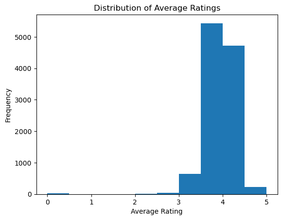

```python
#Plotting a histogram of the average_rating column
plt.hist(data['average_rating'], bins=10)
plt.xlabel('Average Rating')
plt.ylabel('Frequency')
plt.title('Distribution of Average Ratings')
plt.show()
```

# 8.

## Exploring the distribution of numerical column stating number of pages to determine the amount of books having a certain range of pages.

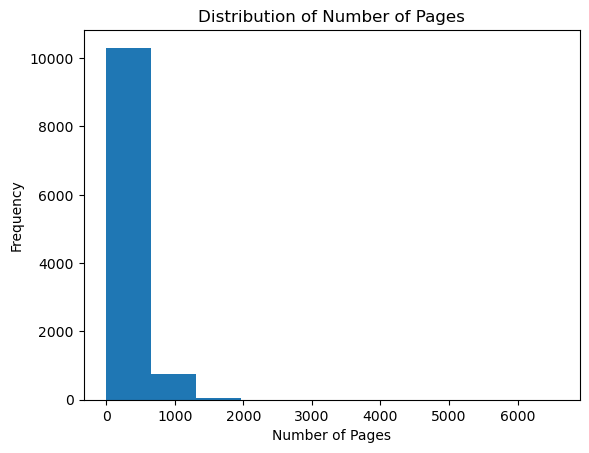

```python
#Plotting a histogram of the num_pages column:
plt.hist(data['  num_pages'], bins=10)
plt.xlabel('Number of Pages')
plt.ylabel('Frequency')
plt.title('Distribution of Number of Pages')
plt.show()
```

# 9.

## Visualizing relationships between variables of average rating and number of pages. This determines the books which have 1-5 scale ratings based on total number of pages.

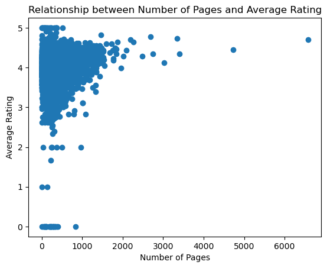

```python
#scatter plot to examine the relationship between num_pages and average_rating
plt.scatter(data['  num_pages'], data['average_rating'])
plt.xlabel('Number of Pages')
plt.ylabel('Average Rating')
plt.title('Relationship between Number of Pages and Average Rating')
plt.show()
```

# 10.

## This is to check if the database have any outliers. Outliers are important because they can have a large influence on statistics derived from the dataset. Outliers are checked for the average_rating column because this is the only column where we can expect an outlier amongst other columns of the dataset.

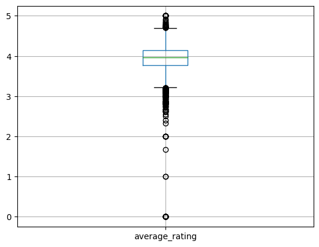

```python
#Boxplot to examine average_rating having any outliers
data[['average_rating']].boxplot()
```

# 11.

## Exploring categorical variables to check their distribution. It enables the identification of patterns and relationships between different categories. This determines the distribution of books across different languages.

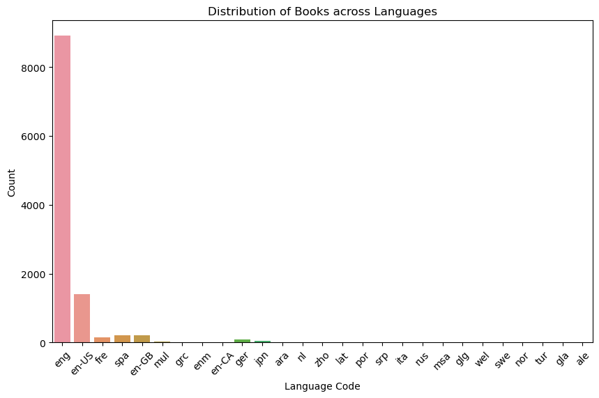

```python
#Bar chart to visualize the distribution of books across different languages
plt.figure(figsize=(10, 6))
# Convert language_code column to string
data['language_code'] = data['language_code'].astype(str)
sns.countplot(data=data, x='language_code')
plt.xlabel('Language Code')
plt.ylabel('Count')
plt.title('Distribution of Books across Languages')
plt.xticks(rotation=45)
plt.show()
```

# 12.

```python
#Converting the publication_date column to a datetime data type
data['publication_date'] = pd.to_datetime(data['publication_date'], errors='coerce')

#Extracting the year from the publication_date column and create a new column
data['publication_year'] = data['publication_date'].dt.year
```

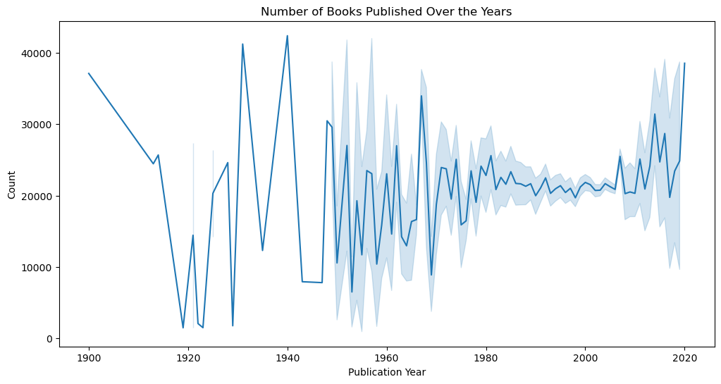

```python
#Plotting a line chart to visualize the number of books published over the years:
plt.figure(figsize=(12, 6))
sns.lineplot(data=data, x='publication_year', y='bookID')
plt.xlabel('Publication Year')
plt.ylabel('Count')
plt.title('Number of Books Published Over the Years')
plt.show()
```

# 13.

## Interactive visualization using plotty. When activated, the interactive plot opens in a separate window, enabling users to explore the data points and view specific details by hovering over them. This determines average rating of a book againtst its total number of pages.

```python
#Using Plotly to create visualizations that allow for zooming, panning, and hover tooltips.
fig = px.scatter(data, x='  num_pages', y='average_rating', hover_data=['title'])
fig.update_layout(title='Interactive Scatter Plot: Number of Pages vs. Average Rating')
fig.show()
```

[interactive chart not shown]

# 14.

## To find the correlation among the variables, it is necessary to use the correlation function. This will give a fair idea of the correlation strength between different variables. If there is strong correlation between two features, one of them can be dropped.

```python
#To check the coreelation between features
data.corr()
```

|  | bookID | average_rating | isbn13 | num_pages | ratings_count | text_reviews_count | publication_year |
| --- | --- | --- | --- | --- | --- | --- | --- |
| bookID | 1.000000 | -0.036207 | -0.002185 | -0.026134 | -0.076820 | -0.081289 | 0.027861 |
| average_rating | -0.036207 | 1.000000 | -0.001965 | 0.150477 | 0.038224 | 0.033663 | -0.031730 |
| isbn13 | -0.002185 | -0.001965 | 1.000000 | -0.009818 | 0.005494 | 0.008152 | -0.000335 |
| num_pages | -0.026134 | 0.150477 | -0.009818 | 1.000000 | 0.034337 | 0.036977 | -0.019259 |
| ratings_count | -0.076820 | 0.038224 | 0.005494 | 0.034337 | 1.000000 | 0.865977 | 0.044542 |
| text_reviews_count | -0.081289 | 0.033663 | 0.008152 | 0.036977 | 0.865977 | 1.000000 | 0.066883 |
| publication_year | 0.027861 | -0.031730 | -0.000335 | -0.019259 | 0.044542 | 0.066883 | 1.000000 |

# 15.

## To find the correlation among the variables through a heatmap.

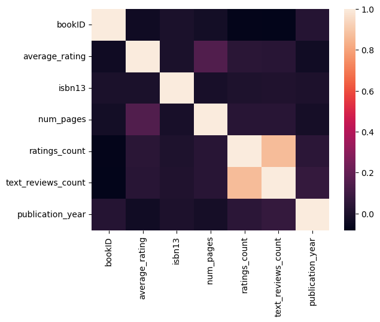

```python
#Correlation plot
sns.heatmap(data.corr())
```

# Task -2 : Feature selection

# 1.

## a) Counting the unique values contained within authors column. This comprehensive analysis aims to determine which of these distinct values have the potential to be used in a grouping framework.

```python
#Counting the authors
data['authors'].value_counts()
```

```
Stephen King                                              40
P.G. Wodehouse                                            40
Rumiko Takahashi                                          39
Orson Scott Card                                          35
Agatha Christie                                           33
                                                          ..
Legs McNeil/Gillian McCain                                 1
Adam Woog                                                  1
Mikal Gilmore                                              1
Thich Nhat Hanh/Arnold Kotler/Dalai Lama XIV               1
William T. Vollmann/Larry McCaffery/Michael Hemmingson     1
Name: authors, Length: 6639, dtype: int64
```

## Since there are more than 50% distinct values. It is suggested not to use authors as a grouping factor because it will not give any meaningful insights as no pattern would be found.

```python
#Looking for unique authors
data['authors'].nunique()
```

```
6639
```

## b) Counting the unique values contained within language_code column.

```python
#Counting total number of languages in which books are written
data['language_code'].value_counts()
```

```
eng      8908
en-US    1408
spa       218
en-GB     214
fre       144
ger        99
jpn        46
mul        19
zho        14
grc        11
por        10
en-CA       7
ita         5
enm         3
lat         3
swe         2
rus         2
srp         1
nl          1
msa         1
glg         1
wel         1
ara         1
nor         1
tur         1
gla         1
ale         1
Name: language_code, dtype: int64
```

## Here the unique values are less than 50%. Lagugage can be used as a grouping factor since english has the most number of records. It holds a majority part in the database

```python
#Looking for unique languages in which books are written
data['language_code'].nunique()
```

```
27
```

## c) Counting the unique values contained within num_pages column.

```python
#Counting the length of each book against the amount of books having such value
data['  num_pages'].value_counts()
```

```
288     230
192     221
320     218
256     207
352     202
       ...
1046      1
976       1
1440      1
25        1
22        1
Name:   num_pages, Length: 997, dtype: int64
```

## The number of total publishers are too high in order to group them with other columns.

```python
#Looking for unique number of pages
data['publisher'].nunique()
```

```
2290
```

## As a result, values are too high for some columns, we cannot use them as a group criteria. Column publisher and authors have large values.

# 2.

## Grouping the selected features of the database on the bases of language_code. This particular feature is used since its value is not too large in order to group the values of other features on the bases of its unique values.

```python
#Grouping selected features on the bases of language_code
df9 = data[['authors','title','average_rating','  num_pages','publisher']].groupby(data['language_code'])
df9.first()
```

| language_code | authors | title | average_rating | num_pages | publisher |
| --- | --- | --- | --- | --- | --- |
| ale | David Gemmell | Shield of Thunder (Troy #2) | 4.36 | 512 | Ballantine Books |
| ara | Sonallah Ibrahim/صنع الله إبراهيم/Anthony Cald... | Zaat | 3.55 | 349 | American University in Cairo Press |
| en-CA | Madeleine L'Engle | A Circle of Quiet (Crosswicks Journals #1) | 4.21 | 246 | HarperOne |
| en-GB | Alice Sebold | The Lovely Bones | 3.81 | 328 | Picador |
| en-US | W. Frederick Zimmerman | Unauthorized Harry Potter Book Seven News: "Ha... | 3.74 | 152 | Nimble Books |
| eng | J.K. Rowling/Mary GrandPré | Harry Potter and the Half-Blood Prince (Harry ... | 4.57 | 652 | Scholastic Inc. |
| enm | Geoffrey Chaucer/Jill Mann | The Canterbury Tales (original-spelling edition) | 3.49 | 1254 | Penguin Classics |
| fre | John McPhee | La Place de la Concorde Suisse | 3.92 | 160 | Farrar Straus and Giroux |
| ger | Tracy Chevalier | Wenn Engel fallen | 3.58 | 384 | List |
| gla | J.K. Rowling | Harry Potter and the Philosopher's Stone (Harr... | 4.47 | 250 | Bloomsbury USA Childrens |
| glg | Manuel Rivas | Os libros arden mal | 3.36 | 741 | Edicións Xerais de Galicia S.A. |
| grc | Euripides/Donald J. Mastronarde | Medea | 3.87 | 431 | Cambridge University Press |
| ita | Sylvia Nasar/Carlo Capararo/Sergio Mancini/Rob... | Il genio dei numeri | 4.13 | 442 | Rizzoli |
| jpn | Tsugumi Ohba/Takeshi Obata/大場 つぐみ/小畑 健 | DEATH NOTE デスノート 1 | 4.43 | 195 | 集英社 |
| lat | Dr. Seuss/Jennifer Morrish Tunberg/Terence Tun... | Cattus Petasatus: The Cat in the Hat in Latin | 4.17 | 75 | Bolchazy-Carducci Publishers |
| msa | Arthur Golden | Kenang-Kenangan Seorang Geisha (Memoirs of a G... | 4.11 | 784 | Marshall Cavendish Editions |
| mul | Michael Ochs/Patrick Javault/Ulrike Wasel | 1000 Record Covers | 3.85 | 575 | Taschen |
| nl | Wally Lamb/Inge de Heer | Vergeef me | 4.18 | 744 | De Boekerij |
| nor | Knut Hamsun/Sverre Lyngstad | In Wonderland | 3.60 | 185 | Ig Publishing |
| por | Joan Didion | O Ano do Pensamento Mágico | 3.89 | 224 | Nova Fronteira |
| rus | Mikhail Bulgakov/Михаил Булгаков | Мастер и Маргарита | 4.30 | 640 | Эксмо |
| spa | Madeleine L'Engle | Una arruga en el tiempo – A Wrinkle in Time | 4.00 | 205 | Turtleback Books |
| srp | Dobrica Erić | Venac sonetnih venaca; Puževa srma | 0.00 | 222 | Izdavačka agencija "Draganić" |
| swe | Lennart Hellsing/Fibben Hald | Verserade tankar | 3.00 | 128 | Alfabeta Bokförlag |
| tur | J.K. Rowling/Sevin Okyay | Harry Potter ve Sırlar Odası (Harry Potter #2) | 4.42 | 403 | Yapı Kredi Yayınları |
| wel | Nicholas Evans/Rhonda Evans | Delwau Duon: Peintiadau Nicholas Evans = Symph... | 5.00 | 150 | Y Lolfa |
| zho | J.K. Rowling/J.K.羅琳/皇冠編譯組/張定綺/彭倩文/趙丕慧/林靜華 | 混血王子的背叛 (哈利波特 #6) | 4.57 | 735 | 皇冠文化出版有限公司 |

## Grouping on the bases of language code. We can see that majority of the books are written in english.

```python
#Checking for eng which has high users and number of books
df10 = df9.get_group('eng')
df10
```

|  | authors | title | average_rating | num_pages | publisher |
| --- | --- | --- | --- | --- | --- |
| 0 | J.K. Rowling/Mary GrandPré | Harry Potter and the Half-Blood Prince (Harry ... | 4.57 | 652 | Scholastic Inc. |
| 1 | J.K. Rowling/Mary GrandPré | Harry Potter and the Order of the Phoenix (Har... | 4.49 | 870 | Scholastic Inc. |
| 2 | J.K. Rowling | Harry Potter and the Chamber of Secrets (Harry... | 4.42 | 352 | Scholastic |
| 3 | J.K. Rowling/Mary GrandPré | Harry Potter and the Prisoner of Azkaban (Harr... | 4.56 | 435 | Scholastic Inc. |
| 4 | J.K. Rowling/Mary GrandPré | Harry Potter Boxed Set Books 1-5 (Harry Potte... | 4.78 | 2690 | Scholastic |
| ... | ... | ... | ... | ... | ... |
| 11103 | Roald Dahl | Fantastic Mr. Fox (Cover to Cover) | 4.05 | 90 | BBC Audiobooks |
| 11118 | William T. Vollmann/Larry McCaffery/Michael He... | Expelled from Eden: A William T. Vollmann Reader | 4.06 | 512 | Da Capo Press |
| 11119 | William T. Vollmann | You Bright and Risen Angels | 4.08 | 635 | Penguin Books |
| 11120 | William T. Vollmann | The Ice-Shirt (Seven Dreams #1) | 3.96 | 415 | Penguin Books |
| 11121 | William T. Vollmann | Poor People | 3.72 | 434 | Ecco |

8908 rows × 5 columns

## Insights:

```python
#we can see the stats of english books
df10.describe()
```

|  | average_rating | num_pages |
| --- | --- | --- |
| count | 8908.000000 | 8908.000000 |
| mean | 3.934062 | 336.797373 |
| std | 0.358838 | 246.372684 |
| min | 0.000000 | 0.000000 |
| 25% | 3.780000 | 194.000000 |
| 50% | 3.960000 | 298.000000 |
| 75% | 4.140000 | 416.000000 |
| max | 5.000000 | 6576.000000 |

```python
#vintage and penguin books are the most famous publisher
df10['publisher'].value_counts()
```

```
Vintage                                        295
Penguin Books                                  232
Penguin Classics                               159
Ballantine Books                               126
Mariner Books                                  121
                                              ...
Joanna Cotler Books                              1
Kindle                                           1
Dedalus Limited                                  1
Turtleback Books Distributed by Demco Media      1
O'Brien Press                                    1
Name: publisher, Length: 1872, dtype: int64
```

```python
#P.G. Wodehouse, Stephen King ,Agatha Christie are the most famous authors of english language
df10['authors'].value_counts()
```

```
P.G. Wodehouse                                        37
Stephen King                                          34
Agatha Christie                                       32
Sandra Brown                                          27
Orson Scott Card                                      26
                                                      ..
Matt Wagner/Rich Rankin/Chris Pitzer/Diana Schutz      1
Kate Chopin/Sandra M. Gilbert                          1
Kate Chopin/Cynthia Brantley Johnson/Alyssa  Harad     1
Michael Wharton                                        1
Unknown/Howell D. Chickering                           1
Name: authors, Length: 5501, dtype: int64
```

## Observation:

### Authors, title, average_rating, num_pages, and publisher are the most informative features since they give an idea of the user's behavior. For example: if a person reads JK Rowling's books, we can identify details from its metadata which include the number of pages, average ratings, publisher, and language. This data helps us to recommend similar titles to the use, based on any of the above features.

### For example: If the user reads Harry Potter and the Order of the Phoenix, we know that the author is JK Rowling and its average rating is 4.49 and the number of page is 870 and the language is English. Hence, with this data, we can recommend books by similar author, ratings, and publisher.

# Task - 3 : Feature engineering

## Feature engineering is a crucial step, involving the creation and selection of meaningful features from raw data. It aims to extract relevant information from the dataset.

## a) Final features are selected

```python
#Final features selected for feature engineering
df_main = data[['authors','title','average_rating','  num_pages','publisher']]
df_main
```

|  | authors | title | average_rating | num_pages | publisher |
| --- | --- | --- | --- | --- | --- |
| 0 | J.K. Rowling/Mary GrandPré | Harry Potter and the Half-Blood Prince (Harry ... | 4.57 | 652 | Scholastic Inc. |
| 1 | J.K. Rowling/Mary GrandPré | Harry Potter and the Order of the Phoenix (Har... | 4.49 | 870 | Scholastic Inc. |
| 2 | J.K. Rowling | Harry Potter and the Chamber of Secrets (Harry... | 4.42 | 352 | Scholastic |
| 3 | J.K. Rowling/Mary GrandPré | Harry Potter and the Prisoner of Azkaban (Harr... | 4.56 | 435 | Scholastic Inc. |
| 4 | J.K. Rowling/Mary GrandPré | Harry Potter Boxed Set Books 1-5 (Harry Potte... | 4.78 | 2690 | Scholastic |
| ... | ... | ... | ... | ... | ... |
| 11118 | William T. Vollmann/Larry McCaffery/Michael He... | Expelled from Eden: A William T. Vollmann Reader | 4.06 | 512 | Da Capo Press |
| 11119 | William T. Vollmann | You Bright and Risen Angels | 4.08 | 635 | Penguin Books |
| 11120 | William T. Vollmann | The Ice-Shirt (Seven Dreams #1) | 3.96 | 415 | Penguin Books |
| 11121 | William T. Vollmann | Poor People | 3.72 | 434 | Ecco |
| 11122 | Mark Twain | Las aventuras de Tom Sawyer | 3.91 | 272 | Edimat Libros |

11123 rows × 5 columns

## b) TF-IDF scores are calculated

### TF-IDF (Term Frequency-Inverse Document Frequency) is a numerical representation used to assess the importance of a term within the data. It calculates a weight for each term based on its frequency within the data.

### TF-IDF is useful because it helps prioritize terms that are both frequently occurring within a document and relatively rare across the entire corpus. By assigning higher weights to these terms, TF-IDF emphasizes their significance in distinguishing documents from one another

```python
#Finding the tf-idf score of each row value against the entire column of the specified column.
vectorizer1 = TfidfVectorizer()
author_tfidf = vectorizer1.fit_transform(data['authors'])

vectorizer2 = TfidfVectorizer()
publisher_tfidf = vectorizer2.fit_transform(data['publisher'])

vectorizer3 = TfidfVectorizer()
title_tfidf = vectorizer3.fit_transform(data['title'])
```

## c) Making a data frame of the TF-IDF n dimension array of each token. The columns of this data frame are the feature names of the vectorizer. Which is the token name itself.

```python
#Making a dataframe of tf-idf of each token
authorscoredf = pd.DataFrame(author_tfidf.toarray(),columns = vectorizer1.get_feature_names_out())
publisherscoredf = pd.DataFrame(publisher_tfidf.toarray(),columns = vectorizer2.get_feature_names_out())
titlescoredf = pd.DataFrame(title_tfidf.toarray(),columns = vectorizer3.get_feature_names_out())
```

## d) Along with the columns, we are finding the sum of the tf-idf score of individual tokens in each row which gives us a combined score for each row.

```python
#Sum of tf-idf score
df_main['author_tfidf']=authorscoredf.sum(axis=1)
df_main['publisher_tfidf']=publisherscoredf.sum(axis=1)
df_main['title_tfidf']=titlescoredf.sum(axis=1)
```

## e) This is the final database to be used to find the cosine similarity against the user input.

```python
#dropping the existing columns from df_main
finaldf = df_main.drop(columns = ['authors','publisher','title'])
finaldf
```

|  | average_rating | num_pages | author_tfidf | publisher_tfidf | title_tfidf |
| --- | --- | --- | --- | --- | --- |
| 0 | 4.57 | 652 | 1.707078 | 1.414213 | 2.313727 |
| 1 | 4.49 | 870 | 1.707078 | 1.414213 | 2.283151 |
| 2 | 4.42 | 352 | 1.000000 | 1.000000 | 2.215815 |
| 3 | 4.56 | 435 | 1.707078 | 1.414213 | 2.235402 |
| 4 | 4.78 | 2690 | 1.707078 | 1.000000 | 2.136048 |
| ... | ... | ... | ... | ... | ... |
| 11118 | 4.06 | 512 | 2.350660 | 1.645106 | 2.393038 |
| 11119 | 4.08 | 635 | 1.356608 | 1.384786 | 2.113178 |
| 11120 | 3.96 | 415 | 1.356608 | 1.384786 | 2.078603 |
| 11121 | 3.72 | 434 | 1.356608 | 1.000000 | 1.397845 |
| 11122 | 3.91 | 272 | 1.400044 | 1.413670 | 2.207367 |

11123 rows × 5 columns

## Checking df_main for tf-idf scores in replacement of actual column values.

```python
#printing df_main
df_main
```

|  | authors | title | average_rating | num_pages | publisher | author_tfidf | publisher_tfidf | title_tfidf |
| --- | --- | --- | --- | --- | --- | --- | --- | --- |
| 0 | J.K. Rowling/Mary GrandPré | Harry Potter and the Half-Blood Prince (Harry ... | 4.57 | 652 | Scholastic Inc. | 1.707078 | 1.414213 | 2.313727 |
| 1 | J.K. Rowling/Mary GrandPré | Harry Potter and the Order of the Phoenix (Har... | 4.49 | 870 | Scholastic Inc. | 1.707078 | 1.414213 | 2.283151 |
| 2 | J.K. Rowling | Harry Potter and the Chamber of Secrets (Harry... | 4.42 | 352 | Scholastic | 1.000000 | 1.000000 | 2.215815 |
| 3 | J.K. Rowling/Mary GrandPré | Harry Potter and the Prisoner of Azkaban (Harr... | 4.56 | 435 | Scholastic Inc. | 1.707078 | 1.414213 | 2.235402 |
| 4 | J.K. Rowling/Mary GrandPré | Harry Potter Boxed Set Books 1-5 (Harry Potte... | 4.78 | 2690 | Scholastic | 1.707078 | 1.000000 | 2.136048 |
| ... | ... | ... | ... | ... | ... | ... | ... | ... |
| 11118 | William T. Vollmann/Larry McCaffery/Michael He... | Expelled from Eden: A William T. Vollmann Reader | 4.06 | 512 | Da Capo Press | 2.350660 | 1.645106 | 2.393038 |
| 11119 | William T. Vollmann | You Bright and Risen Angels | 4.08 | 635 | Penguin Books | 1.356608 | 1.384786 | 2.113178 |
| 11120 | William T. Vollmann | The Ice-Shirt (Seven Dreams #1) | 3.96 | 415 | Penguin Books | 1.356608 | 1.384786 | 2.078603 |
| 11121 | William T. Vollmann | Poor People | 3.72 | 434 | Ecco | 1.356608 | 1.000000 | 1.397845 |
| 11122 | Mark Twain | Las aventuras de Tom Sawyer | 3.91 | 272 | Edimat Libros | 1.400044 | 1.413670 | 2.207367 |

11123 rows × 8 columns

## f) Fetching the information that the user entered and performing a transformation on it. Similar steps are followed with the information given by the user. Including Finding the tf-idf score, making a dataframe of each token and finding the sum of scores to be compared against author and title.

## This is done because the transformation which is done with reference data should be done with the user input data as well. (Cannot do cosine similarity on a string)

## Will match the index of the top 5 cosine distances with the dataframe to get the actual recommendations.

## When the user will enter the information, it will be converted into a score. Then that score will be compared with final_df.

```python
#final_df and df_main are here just for comparision and getting the recommendations against the user input value

def get_recommendations(authors, title, finaldf, df_main):
    #Converting string into dataframe
    data = {'authors':[authors], 'title':[title]}
    newdf = pd.DataFrame(data)

    #Finding the tf-idf score of each row value against the entire column of the specified column.
    vectorizer4 = TfidfVectorizer()
    authornew_tfidf = vectorizer4.fit_transform(newdf['authors'])
    vectorizer5 = TfidfVectorizer()
    titlenew_tfidf = vectorizer5.fit_transform(newdf['title'])

    #Making a dataframe of tf-idf of each token
    authornewscoredf = pd.DataFrame(authornew_tfidf.toarray(),columns = vectorizer4.get_feature_names_out())
    titlenewscoredf = pd.DataFrame(titlenew_tfidf.toarray(),columns = vectorizer5.get_feature_names_out())

    #Sum of tf-idf score
    newdf['authornew_tfidf']=authornewscoredf.sum(axis=1)
    newdf['titlenew_tfidf']=titlenewscoredf.sum(axis=1)

    #Dropping the existing columns from df_main
    finaldf1 = newdf.drop(columns = ['authors','title'])

    #Comparing it with author and title
    cos_sim = cosine_similarity(finaldf[['author_tfidf','title_tfidf']],finaldf1)

    #Then storing it in a df
    cosine_sim_df = pd.DataFrame(cos_sim)

    #Get top 5 rows with highest cosine similarity scores
    top_5_rows = cosine_sim_df.stack().nlargest(5).reset_index()
    top_5_rows.columns = ['row1', 'row2', 'similarity']

    #Get text values of top 5 rows
    top_5_text = df_main.iloc[top_5_rows['row1'].values][['title','authors']].values

    #Returning the top 5 rows with similarity
    return top_5_text, top_5_rows['similarity']
```

```python
#User entered information
recommendations, similarity = get_recommendations('William T. Vollmann','Poor People',finaldf, df_main)
```

```python
#Checking similarity against the user entered data
finaloutput = pd.DataFrame(recommendations, columns = ['title','authors'])
finaloutput['similarity']= similarity
```

```python
finaloutput
```

|  | title | authors | similarity |
| --- | --- | --- | --- |
| 0 | Strong Opinions | Vladimir Nabokov | 1.0 |
| 1 | A Complicated Kindness | Miriam Toews | 1.0 |
| 2 | African Nights | Kuki Gallmann | 1.0 |
| 3 | Clay's Quilt | Silas House | 1.0 |
| 4 | Maurice | E.M. Forster | 1.0 |